# DataAnalysis - Postprocessing Results MaxQuant

26 Juli 2022, 09:20:57

# 1 Global Parameters

```r
###############################
#
#define settings
#
###############################

GET_SAMPLE_NAMES <- TRUE # if set to FALSE define it in the next line
#sample_names_user <- c()

unique <- params$unique  # how many peptides should be at least necessary to identify a protein


# which types should be evaluated TRUE or FALSE could be used
RAZOR <- FALSE
UNIQUE <- FALSE
LFQ <- FALSE
if (any(grepl("RAZOR",params$protein_types))){
  RAZOR <- TRUE
}
if (any(grepl("UNIQUE",params$protein_types))){
  UNIQUE <- TRUE
}
if (any(grepl("LFQ",params$protein_types))){
  LFQ <- TRUE
}

# define path of the proteinGroups.txt file(s)
path = params$path

# save files | options
# FALSE - results are not saved
# "RDS" - save results into R data file format
# "CSV" - save results into a csv file
SAVE <- "FALSE"
if (any(grepl("RDS",params$SAVE))){
  SAVE <- "RDS"
}
if (any(grepl("CSV",params$SAVE))){
  SAVE <- "CSV"
}
```

# 2 Introduction

## 2.1 Unique | Razor&Unique procedure

Filtering:

- `Potential.contaminant != "+"` -> remove where contaminants
- `Reverse != "+"`-> remove where reverse = +
- `Only.identified.by.site != "+"` -> remove where only identified by site = +
- `data[name] >= unique` -> keep only identifications which have greater or equal number (defined via variable `unique`) of `razor/unique peptides` | typically this is set to 1 or 2

`Data analysis` show the number of identified proteins and the heatmap. In `Summary` the final results are visualized as boxplot and a table with the summarized values is shown.

## 2.2 LFQ-Procedure

Filtering:

- `Potential.contaminant != "+"` -> remove where contaminants = +
- `Reverse != "+"`-> remove where reverse = +
- `Only.identified.by.site != "+"` -> remove where only identified by site = +

Then the `log2`of the LFQ intensities is calculated and all `-Inf` values were substituted by NA using the following command: `lfq[lfq == -Inf] <- NA`

`Data analysis` show the number of identified proteins and the heatmap. In `Summary` the final results are visualized as boxplot and a table with the summarized values is shown.

# 3 Load required packages and functions

```r
# load libraries
library(tidyverse)
library(dplyr)
library(pheatmap)
library(ggplot2)
library(reshape)
library(knitr)
# load functions
filtering <- function(d){
  data_raw %>% filter(
    Potential.contaminant != "+",
    Reverse != "+",
    Only.identified.by.site != "+")
}
print("loading sucessful")
```

```
## [1] "loading sucessful"
```

# 4 Data Analysis

The txt-files of the defined folder are read in, processed and filtered automatically. This section shows the code, heatmaps for LFQ values and also some summary statistics.

```r
########## read in all data with pattern .txt
# get file list
file.list <- list.files(path = path, pattern='*.txt')
# create file path
file.path <- paste(path,file.list,sep = "")
# read in files - for each file one variable is created - results are stored in a list
res_raw <- lapply(file.path, read.delim)
names(res_raw) <- file.list

########## get sample names
if (GET_SAMPLE_NAMES == TRUE){
  #get sample names
  tmp <- colnames(res_raw[[1]])
  tmp <- tmp[grep("Razor...unique.peptides.",tmp)]
  tmp <- sub(".*Razor...unique.peptides.", "",tmp)
  sample_names_raw <- tmp
  rm(tmp)
  #create sample names
  sample_names_razor <- paste("Razor...unique.peptides.",sample_names_raw, sep="")
  sample_names_unique <- paste("Unique.peptides.",sample_names_raw, sep="")
  sample_names_lfq <- paste("LFQ.intensity.",sample_names_raw, sep="")
} else {
  for (i in 1:length(file.list)){
    # rename columns
    res_raw[[i]] <- res_raw[[i]] %>%
       rename_with(~ paste("Razor_", sample_names_user, sep = ""),
                   starts_with("Razor...unique.peptides.")) %>%
       rename_with(~ paste("Unique_", sample_names_user, sep = ""),
                   starts_with("Unique.peptides.")) %>%
       rename_with(~ paste("LFQ_", sample_names_user, sep = ""),
                   starts_with("LFQ.intensity."))
    # get column names
    sample_names_razor <- colnames(res_raw[[i]][grep("Razor_",
                                                colnames(res_raw[[i]]))])
    sample_names_unique <- colnames(res_raw[[i]][grep("Unique_",
                                                colnames(res_raw[[i]]))])
    sample_names_lfq <- colnames(res_raw[[i]][grep("LFQ_",
                                                 colnames(res_raw[[i]]))])
    }
}

########## create result data frame & result lists
# create data frame for razor
results_2gether_razor <- data.frame(matrix(ncol = length(sample_names_razor), nrow = length(file.list)))
row.names(results_2gether_razor) <- file.list
colnames(results_2gether_razor) <- sample_names_razor
#create data frame for unique
results_2gether_unique <- data.frame(matrix(ncol = length(sample_names_unique), nrow = length(file.list)))
row.names(results_2gether_unique) <- file.list
colnames(results_2gether_unique) <- sample_names_unique
#create data frame for lfq
results_2gether_lfq <- data.frame(matrix(ncol = length(sample_names_lfq), nrow = length(file.list)))
row.names(results_2gether_lfq) <- file.list
colnames(results_2gether_lfq) <- sample_names_lfq

#results lists
results_razor <- list()
results_unique <- list()
results_lfq <- list()

########## perform evaluation
if (RAZOR == TRUE) {
  cat("\n")
  cat("##","Razor","\n")
  cat("\n")
  for (x in file.list){
    cat("\n")
    cat("###",substring(x, 1, nchar(x)-4),"\n")
    data_raw <- as.data.frame(res_raw[[x]])
    data <- filtering(data_raw)
    results <- data.frame(matrix(ncol = length(sample_names_razor), nrow = nrow(data)))
    colnames(results) <- sample_names_razor
    i <- 0
    for (i in 1:length(sample_names_razor)){
      name <- sample_names_razor[i]
      tmp <- (data[name] >= unique)
      results[i] <- tmp
      cat(name,"<br/>",sum(tmp, na.rm = TRUE),"<br/>")
    }
    results_razor[[x]] <- results
    results_2gether_razor[x,] <- sapply(results,function(x)sum(x, na.rm = TRUE))
    cat("\n")

        #create heatmaps
    paletteLength <- 2
    myColor <- colorRampPalette(c("navy", "white",
                                  "firebrick3"))(paletteLength)
      data4pheatmap <- results
      data4pheatmap <- results
      data4pheatmap <- data4pheatmap*1
      data4pheatmap[data4pheatmap == 0] <- NA
      # remove NA rows
      ind <- apply(data4pheatmap, 1, function(x) all(is.na(x)))
      data4pheatmap_clear <- data4pheatmap[!ind,]
      data4pheatmap_clear[is.na(data4pheatmap_clear)] <- 0
      if (ncol(data4pheatmap_clear) < 2){
        cat("\n")
        cat("##"," No heatmap possible. Too less columns in the result
            table.","\n")
      } else {
        pheatmap(data4pheatmap_clear,
                 legend_breaks = c(0,1),
                 color = myColor,
                 treeheight_row = 10,
                 angle_col ="45",
                 treeheight_col = 10,
                 legend = TRUE,
                 labels_row = rep("",nrow(data4pheatmap)),
                 labels_col = sample_names_raw)
        cat("\n")
      }
  }
}
```

## 4.1 Razor

### 4.1.1 results_run1_mqpar_20220406_TR_QC_MBR_rerun_4masterthesis_combined_txt_proteinGroups

Razor…unique.peptides.QC_01_20220406155633  
1327  
Razor…unique.peptides.QC_02  
1363  
Razor…unique.peptides.QC_03  
1351  
Razor…unique.peptides.QC_04  
1357  
Razor…unique.peptides.QC_05  
1371  
Razor…unique.peptides.QC_06  
1374  
Razor…unique.peptides.QC_07  
1397  
Razor…unique.peptides.QC_08  
1372  
Razor…unique.peptides.QC_09  
1338  
Razor…unique.peptides.QC_10  
1330

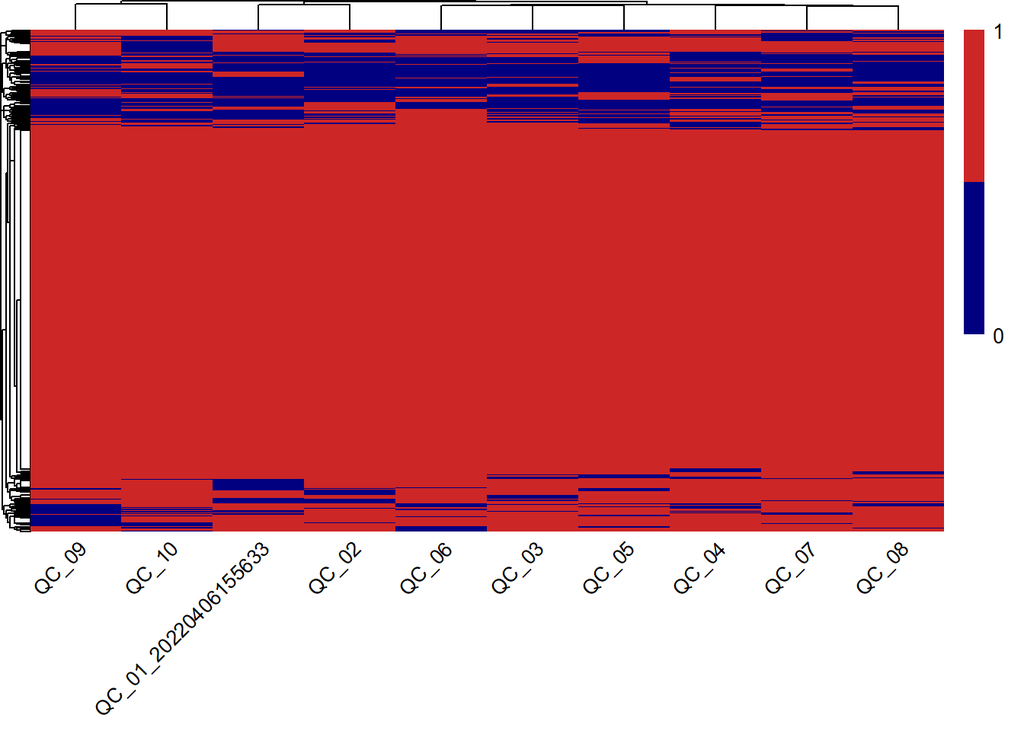

### 4.1.2 results_run10_mqpar_20220406_TR_QC_MBR_rerun_4masterthesis_combined_txt_proteinGroups

Razor…unique.peptides.QC_01_20220406155633  
1310  
Razor…unique.peptides.QC_02  
1344  
Razor…unique.peptides.QC_03  
1335  
Razor…unique.peptides.QC_04  
1313  
Razor…unique.peptides.QC_05  
1343  
Razor…unique.peptides.QC_06  
1317  
Razor…unique.peptides.QC_07  
1333  
Razor…unique.peptides.QC_08  
1343  
Razor…unique.peptides.QC_09  
1279  
Razor…unique.peptides.QC_10  
1297

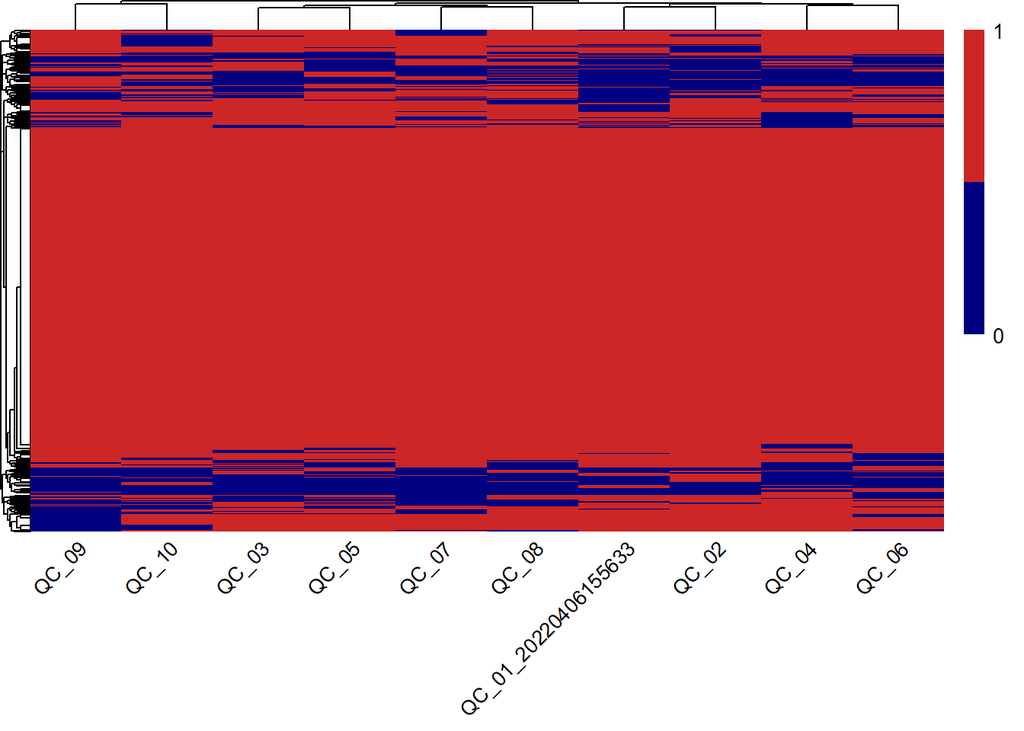

### 4.1.3 results_run2_mqpar_20220406_TR_QC_MBR_rerun_4masterthesis_combined_txt_proteinGroups

Razor…unique.peptides.QC_01_20220406155633  
1323  
Razor…unique.peptides.QC_02  
1357  
Razor…unique.peptides.QC_03  
1350  
Razor…unique.peptides.QC_04  
1356  
Razor…unique.peptides.QC_05  
1366  
Razor…unique.peptides.QC_06  
1372  
Razor…unique.peptides.QC_07  
1384  
Razor…unique.peptides.QC_08  
1375  
Razor…unique.peptides.QC_09  
1332  
Razor…unique.peptides.QC_10  
1332

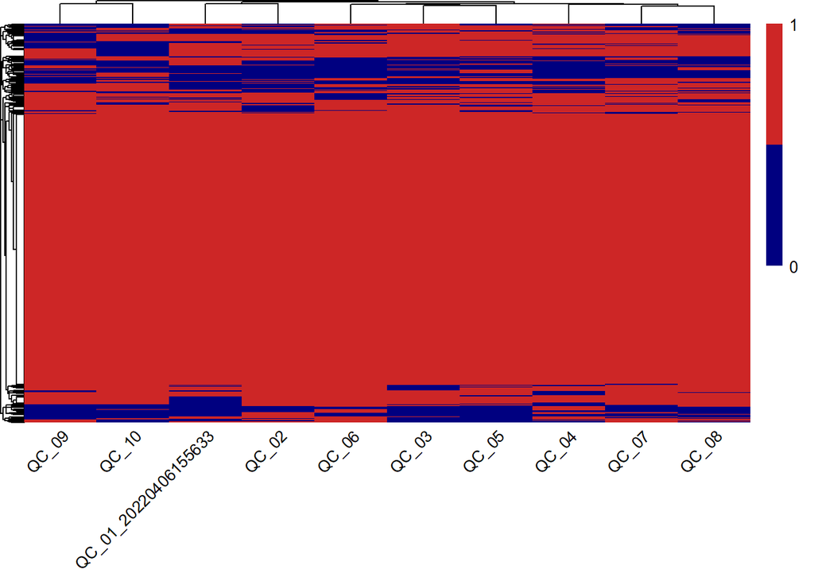

### 4.1.4 results_run3_mqpar_20220406_TR_QC_MBR_rerun_4masterthesis_combined_txt_proteinGroups

Razor…unique.peptides.QC_01_20220406155633  
1324  
Razor…unique.peptides.QC_02  
1363  
Razor…unique.peptides.QC_03  
1350  
Razor…unique.peptides.QC_04  
1354  
Razor…unique.peptides.QC_05  
1372  
Razor…unique.peptides.QC_06  
1376  
Razor…unique.peptides.QC_07  
1395  
Razor…unique.peptides.QC_08  
1373  
Razor…unique.peptides.QC_09  
1342  
Razor…unique.peptides.QC_10  
1331

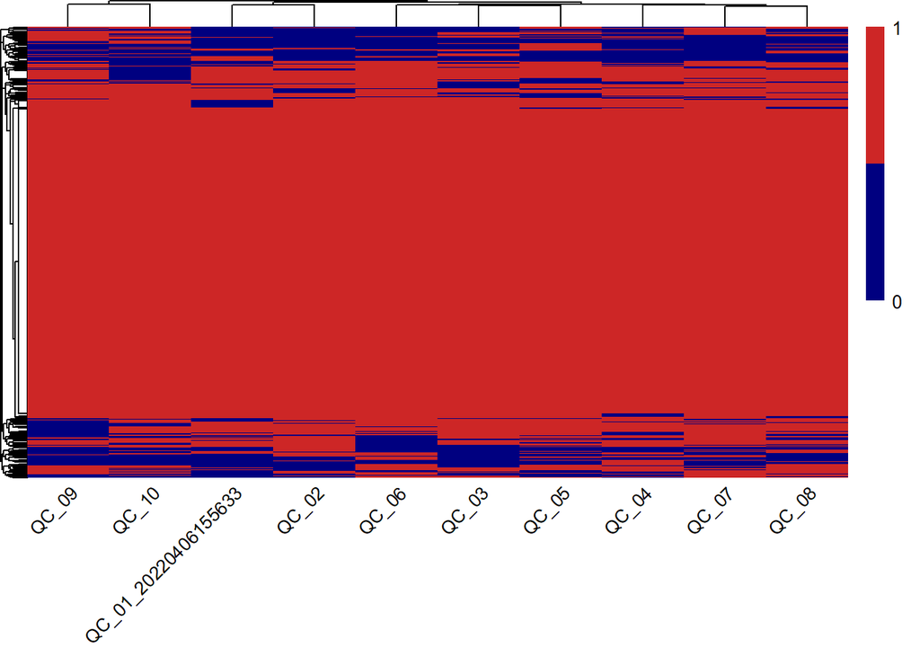

### 4.1.5 results_run4_mqpar_20220406_TR_QC_MBR_rerun_4masterthesis_combined_txt_proteinGroups

Razor…unique.peptides.QC_01_20220406155633  
1320  
Razor…unique.peptides.QC_02  
1353  
Razor…unique.peptides.QC_03  
1346  
Razor…unique.peptides.QC_04  
1349  
Razor…unique.peptides.QC_05  
1362  
Razor…unique.peptides.QC_06  
1370  
Razor…unique.peptides.QC_07  
1382  
Razor…unique.peptides.QC_08  
1371  
Razor…unique.peptides.QC_09  
1317  
Razor…unique.peptides.QC_10  
1330

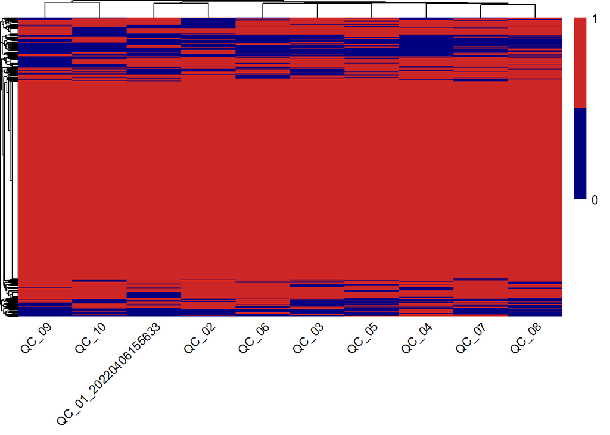

### 4.1.6 results_run5_mqpar_20220406_TR_QC_MBR_rerun_4masterthesis_combined_txt_proteinGroups

Razor…unique.peptides.QC_01_20220406155633  
1327  
Razor…unique.peptides.QC_02  
1361  
Razor…unique.peptides.QC_03  
1350  
Razor…unique.peptides.QC_04  
1354  
Razor…unique.peptides.QC_05  
1370  
Razor…unique.peptides.QC_06  
1373  
Razor…unique.peptides.QC_07  
1394  
Razor…unique.peptides.QC_08  
1372  
Razor…unique.peptides.QC_09  
1336  
Razor…unique.peptides.QC_10  
1330

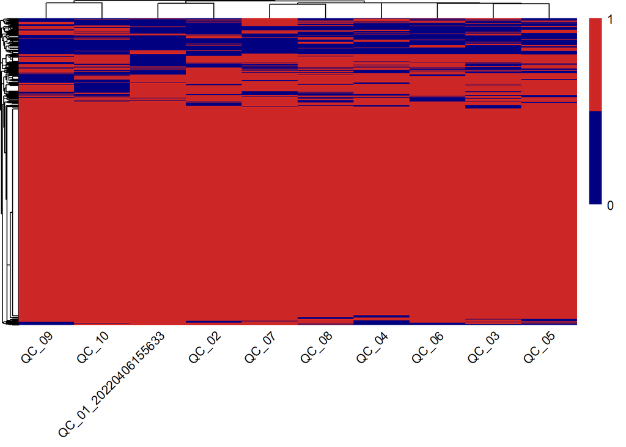

### 4.1.7 results_run6_mqpar_20220406_TR_QC_MBR_rerun_4masterthesis_combined_txt_proteinGroups

Razor…unique.peptides.QC_01_20220406155633  
1310  
Razor…unique.peptides.QC_02  
1345  
Razor…unique.peptides.QC_03  
1337  
Razor…unique.peptides.QC_04  
1315  
Razor…unique.peptides.QC_05  
1347  
Razor…unique.peptides.QC_06  
1331  
Razor…unique.peptides.QC_07  
1356  
Razor…unique.peptides.QC_08  
1344  
Razor…unique.peptides.QC_09  
1282  
Razor…unique.peptides.QC_10  
1300

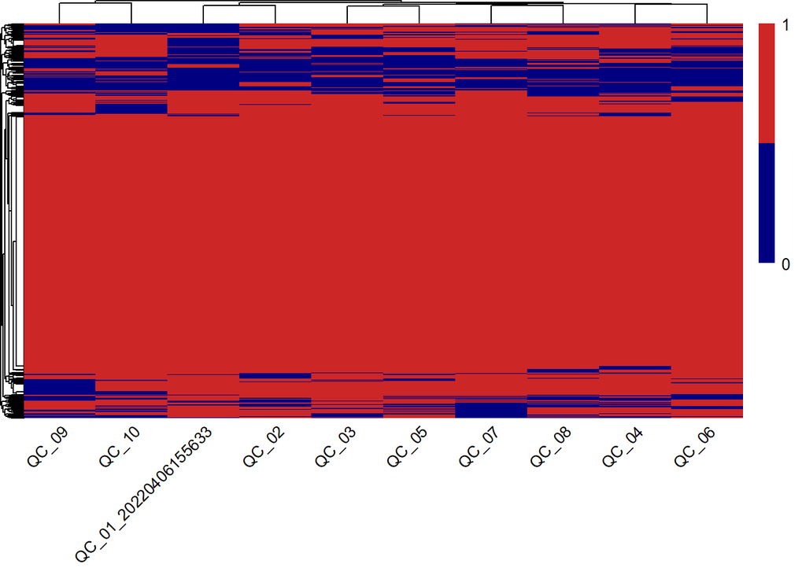

### 4.1.8 results_run7_mqpar_20220406_TR_QC_MBR_rerun_4masterthesis_combined_txt_proteinGroups

Razor…unique.peptides.QC_01_20220406155633  
1328  
Razor…unique.peptides.QC_02  
1362  
Razor…unique.peptides.QC_03  
1350  
Razor…unique.peptides.QC_04  
1351  
Razor…unique.peptides.QC_05  
1372  
Razor…unique.peptides.QC_06  
1373  
Razor…unique.peptides.QC_07  
1393  
Razor…unique.peptides.QC_08  
1370  
Razor…unique.peptides.QC_09  
1336  
Razor…unique.peptides.QC_10  
1332

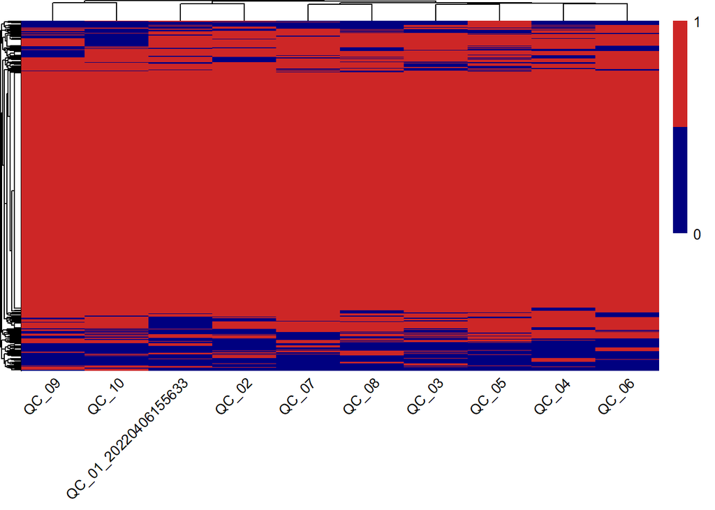

### 4.1.9 results_run8_mqpar_20220406_TR_QC_MBR_rerun_4masterthesis_combined_txt_proteinGroups

Razor…unique.peptides.QC_01_20220406155633  
1313  
Razor…unique.peptides.QC_02  
1354  
Razor…unique.peptides.QC_03  
1344  
Razor…unique.peptides.QC_04  
1335  
Razor…unique.peptides.QC_05  
1348  
Razor…unique.peptides.QC_06  
1347  
Razor…unique.peptides.QC_07  
1357  
Razor…unique.peptides.QC_08  
1357  
Razor…unique.peptides.QC_09  
1298  
Razor…unique.peptides.QC_10  
1311

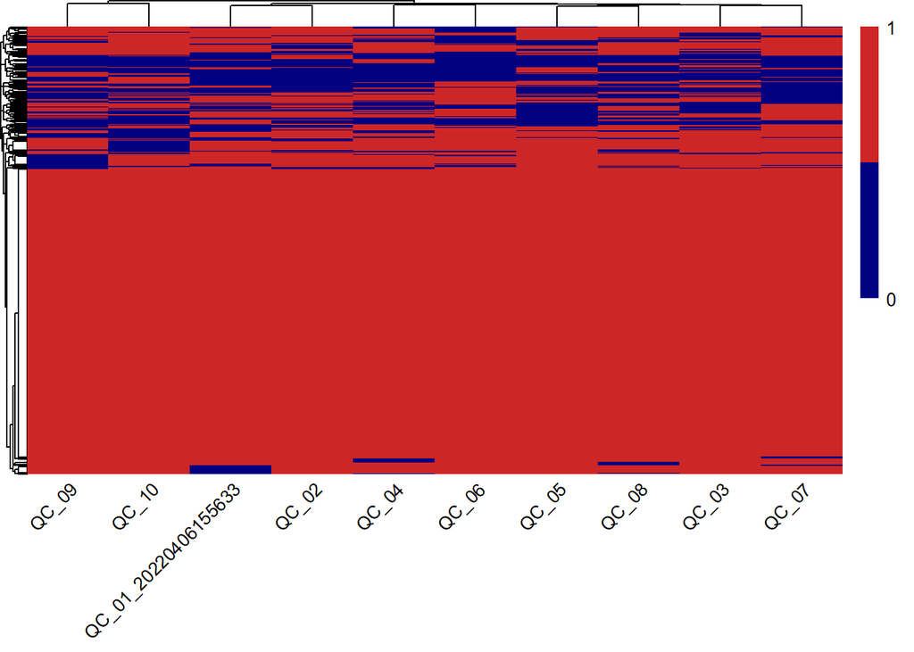

### 4.1.10 results_run9_mqpar_20220406_TR_QC_MBR_rerun_4masterthesis_combined_txt_proteinGroups

Razor…unique.peptides.QC_01_20220406155633  
1325  
Razor…unique.peptides.QC_02  
1359  
Razor…unique.peptides.QC_03  
1345  
Razor…unique.peptides.QC_04  
1345  
Razor…unique.peptides.QC_05  
1370  
Razor…unique.peptides.QC_06  
1375  
Razor…unique.peptides.QC_07  
1392  
Razor…unique.peptides.QC_08  
1368  
Razor…unique.peptides.QC_09  
1337  
Razor…unique.peptides.QC_10  
1333

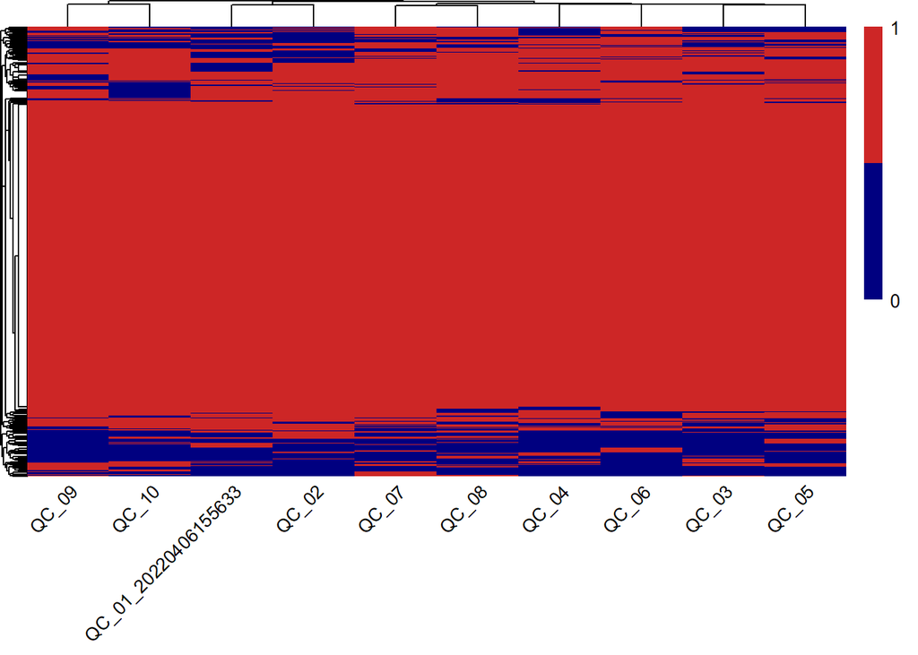

```r
if (UNIQUE == TRUE) {
  cat("\n")
  cat("##","Unique","\n")
  cat("\n")
  for (x in file.list){
    cat("\n")
    cat("###",substring(x, 1, nchar(x)-4),"\n")
    data_raw <- as.data.frame(res_raw[[x]])
    data <- filtering(data_raw)
    results <- data.frame(matrix(ncol = length(sample_names_unique), nrow = nrow(data)))
    colnames(results) <- sample_names_unique
    i <- 0
    for (i in 1:length(sample_names_unique)){
      name <- sample_names_unique[i]
      tmp <- (data[name] >= unique)
      results[i] <- tmp
      cat(name,"<br/>",sum(tmp, na.rm = TRUE),"<br/>")
    }
    results_unique[[x]] <- results
    results_2gether_unique[x,] <- sapply(results,function(x)sum(x, na.rm = TRUE))
    cat("\n")
    #create heatmaps
    paletteLength <- 2
    myColor <- colorRampPalette(c("navy", "white",
                                  "firebrick3"))(paletteLength)
      data4pheatmap <- results
      data4pheatmap <- data4pheatmap*1
      data4pheatmap[data4pheatmap == 0] <- NA
      # remove NA rows
      ind <- apply(data4pheatmap, 1, function(x) all(is.na(x)))
      data4pheatmap_clear <- data4pheatmap[!ind,]
      data4pheatmap_clear[is.na(data4pheatmap_clear)] <- 0
      if (ncol(data4pheatmap) < 2){
        cat("\n")
        cat("##"," No heatmap possible. Too less columns in the result
            table.","\n")
      } else {
        pheatmap(data4pheatmap_clear,
                 legend_breaks = c(0,1),
                 color = myColor,
                 treeheight_row = 10,
                 angle_col ="45",
                 treeheight_col = 10,
                 legend = TRUE,
                 labels_row = rep("",nrow(data4pheatmap)),
                 labels_col = sample_names_raw)
        cat("\n")
      }
  }
}
```

## 4.2 Unique

### 4.2.1 results_run1_mqpar_20220406_TR_QC_MBR_rerun_4masterthesis_combined_txt_proteinGroups

Unique.peptides.QC_01_20220406155633  
1296  
Unique.peptides.QC_02  
1332  
Unique.peptides.QC_03  
1323  
Unique.peptides.QC_04  
1329  
Unique.peptides.QC_05  
1341  
Unique.peptides.QC_06  
1347  
Unique.peptides.QC_07  
1368  
Unique.peptides.QC_08  
1347  
Unique.peptides.QC_09  
1308  
Unique.peptides.QC_10  
1299

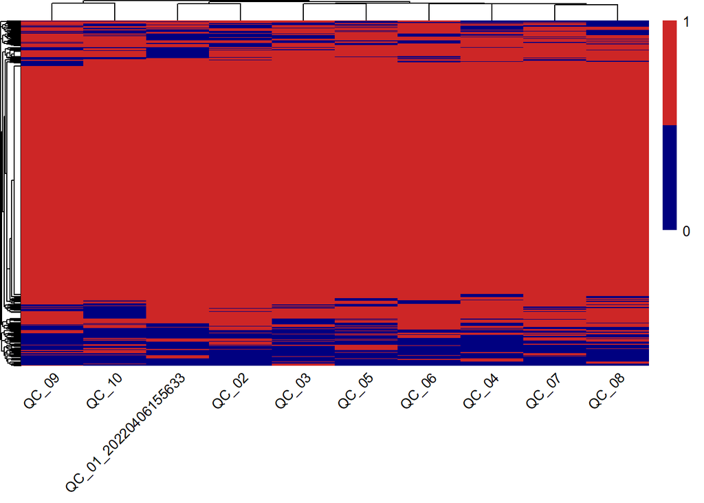

### 4.2.2 results_run10_mqpar_20220406_TR_QC_MBR_rerun_4masterthesis_combined_txt_proteinGroups

Unique.peptides.QC_01_20220406155633  
1281  
Unique.peptides.QC_02  
1314  
Unique.peptides.QC_03  
1309  
Unique.peptides.QC_04  
1288  
Unique.peptides.QC_05  
1314  
Unique.peptides.QC_06  
1290  
Unique.peptides.QC_07  
1303  
Unique.peptides.QC_08  
1319  
Unique.peptides.QC_09  
1250  
Unique.peptides.QC_10  
1266

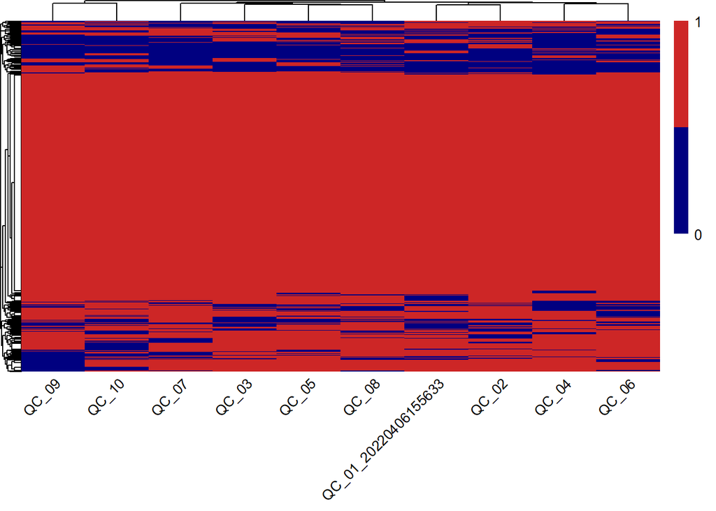

### 4.2.3 results_run2_mqpar_20220406_TR_QC_MBR_rerun_4masterthesis_combined_txt_proteinGroups

Unique.peptides.QC_01_20220406155633  
1292  
Unique.peptides.QC_02  
1326  
Unique.peptides.QC_03  
1325  
Unique.peptides.QC_04  
1329  
Unique.peptides.QC_05  
1337  
Unique.peptides.QC_06  
1344  
Unique.peptides.QC_07  
1355  
Unique.peptides.QC_08  
1349  
Unique.peptides.QC_09  
1302  
Unique.peptides.QC_10  
1302

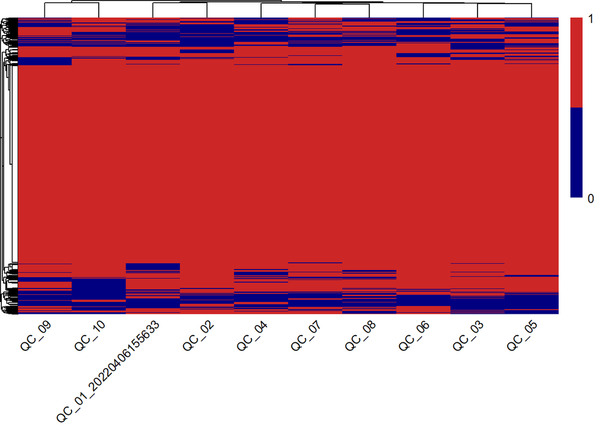

### 4.2.4 results_run3_mqpar_20220406_TR_QC_MBR_rerun_4masterthesis_combined_txt_proteinGroups

Unique.peptides.QC_01_20220406155633  
1292  
Unique.peptides.QC_02  
1332  
Unique.peptides.QC_03  
1322  
Unique.peptides.QC_04  
1326  
Unique.peptides.QC_05  
1342  
Unique.peptides.QC_06  
1349  
Unique.peptides.QC_07  
1367  
Unique.peptides.QC_08  
1347  
Unique.peptides.QC_09  
1311  
Unique.peptides.QC_10  
1299

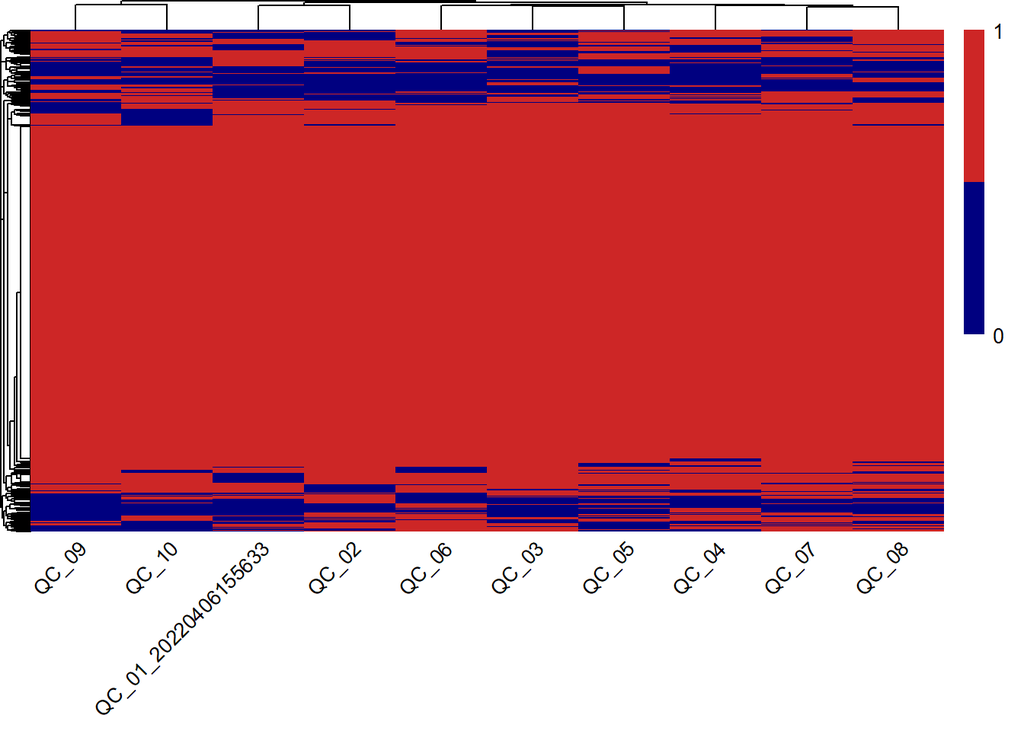

### 4.2.5 results_run4_mqpar_20220406_TR_QC_MBR_rerun_4masterthesis_combined_txt_proteinGroups

Unique.peptides.QC_01_20220406155633  
1289  
Unique.peptides.QC_02  
1321  
Unique.peptides.QC_03  
1321  
Unique.peptides.QC_04  
1323  
Unique.peptides.QC_05  
1333  
Unique.peptides.QC_06  
1345  
Unique.peptides.QC_07  
1353  
Unique.peptides.QC_08  
1347  
Unique.peptides.QC_09  
1287  
Unique.peptides.QC_10  
1300

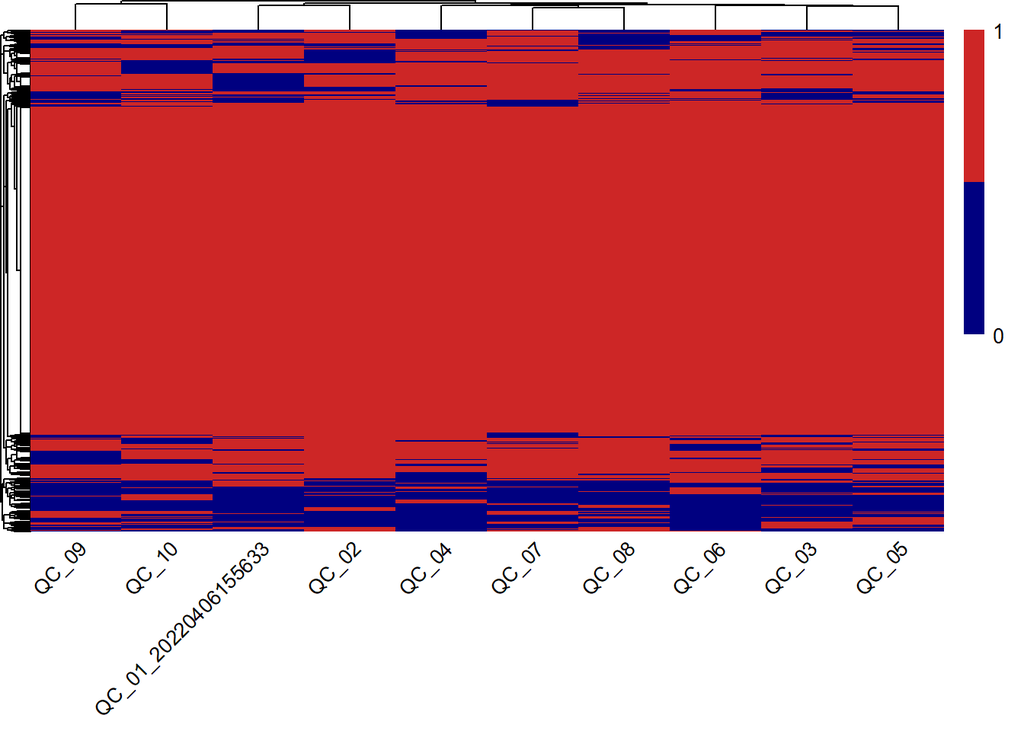

### 4.2.6 results_run5_mqpar_20220406_TR_QC_MBR_rerun_4masterthesis_combined_txt_proteinGroups

Unique.peptides.QC_01_20220406155633  
1295  
Unique.peptides.QC_02  
1330  
Unique.peptides.QC_03  
1322  
Unique.peptides.QC_04  
1326  
Unique.peptides.QC_05  
1340  
Unique.peptides.QC_06  
1345  
Unique.peptides.QC_07  
1365  
Unique.peptides.QC_08  
1346  
Unique.peptides.QC_09  
1305  
Unique.peptides.QC_10  
1297

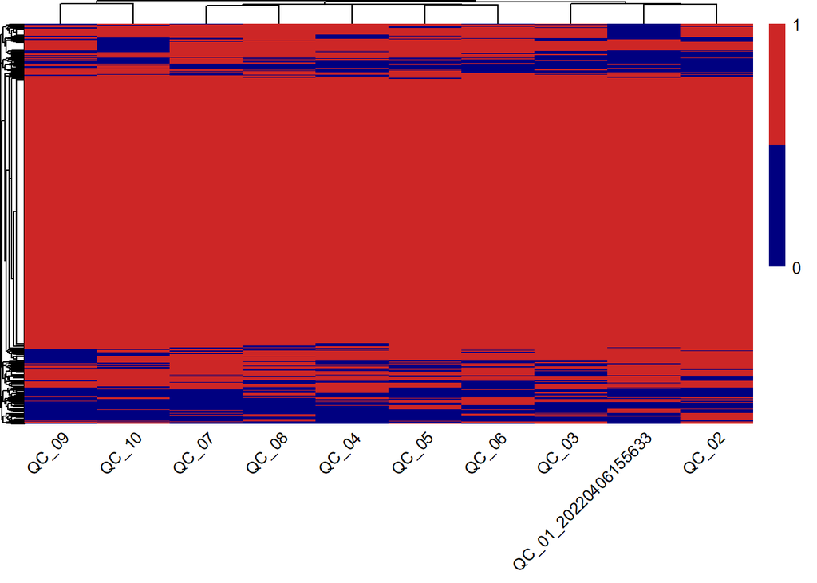

### 4.2.7 results_run6_mqpar_20220406_TR_QC_MBR_rerun_4masterthesis_combined_txt_proteinGroups

Unique.peptides.QC_01_20220406155633  
1282  
Unique.peptides.QC_02  
1315  
Unique.peptides.QC_03  
1310  
Unique.peptides.QC_04  
1290  
Unique.peptides.QC_05  
1320  
Unique.peptides.QC_06  
1305  
Unique.peptides.QC_07  
1328  
Unique.peptides.QC_08  
1320  
Unique.peptides.QC_09  
1253  
Unique.peptides.QC_10  
1269

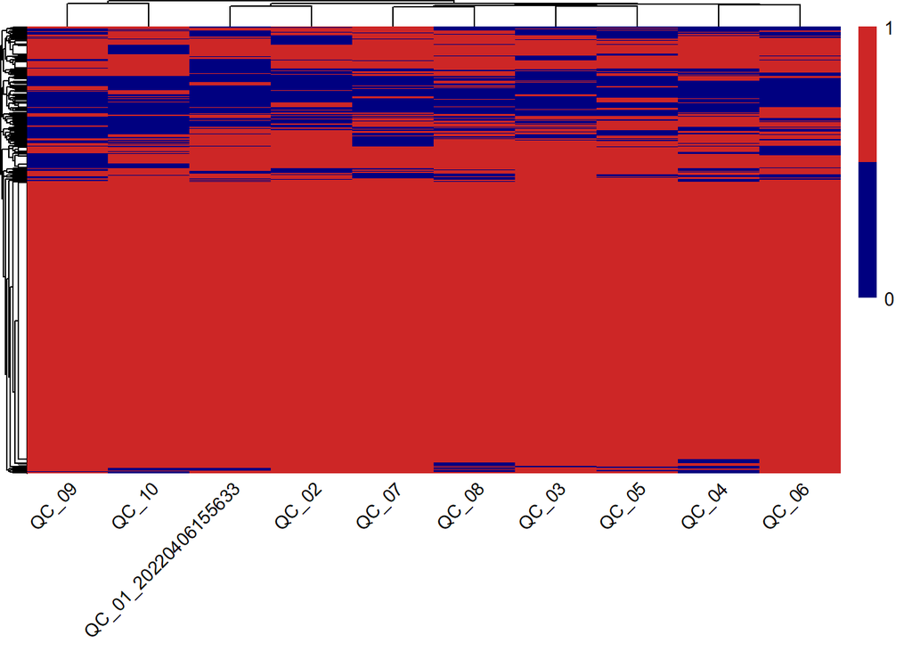

### 4.2.8 results_run7_mqpar_20220406_TR_QC_MBR_rerun_4masterthesis_combined_txt_proteinGroups

Unique.peptides.QC_01_20220406155633  
1296  
Unique.peptides.QC_02  
1331  
Unique.peptides.QC_03  
1323  
Unique.peptides.QC_04  
1322  
Unique.peptides.QC_05  
1341  
Unique.peptides.QC_06  
1344  
Unique.peptides.QC_07  
1365  
Unique.peptides.QC_08  
1344  
Unique.peptides.QC_09  
1304  
Unique.peptides.QC_10  
1301

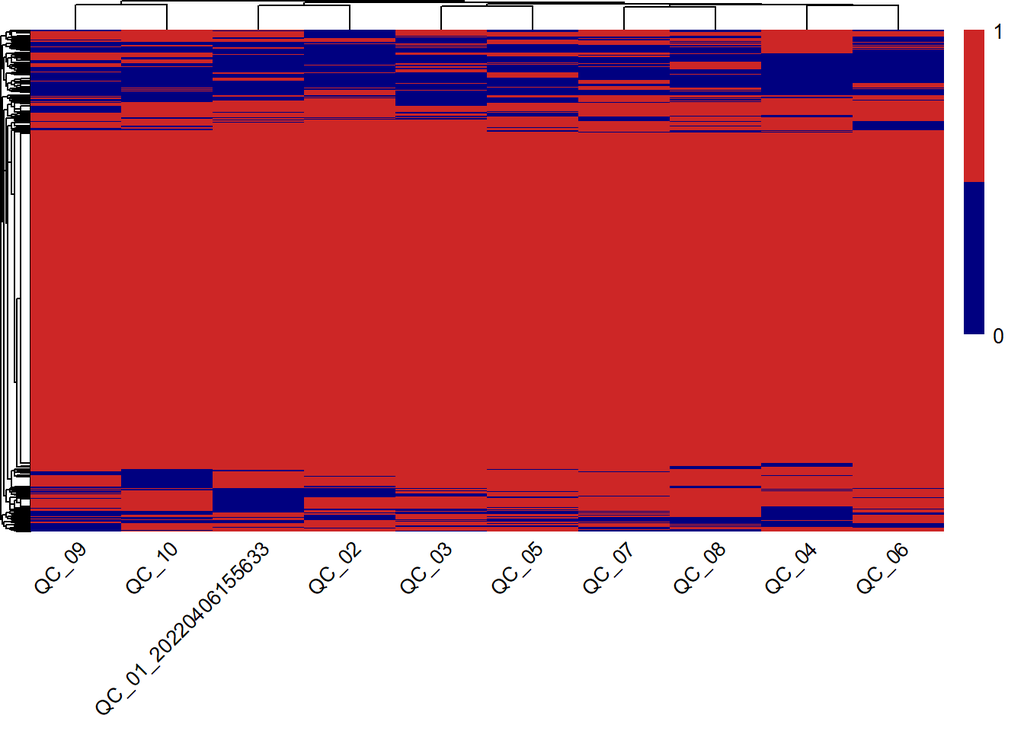

### 4.2.9 results_run8_mqpar_20220406_TR_QC_MBR_rerun_4masterthesis_combined_txt_proteinGroups

Unique.peptides.QC_01_20220406155633  
1284  
Unique.peptides.QC_02  
1324  
Unique.peptides.QC_03  
1319  
Unique.peptides.QC_04  
1309  
Unique.peptides.QC_05  
1321  
Unique.peptides.QC_06  
1322  
Unique.peptides.QC_07  
1330  
Unique.peptides.QC_08  
1334  
Unique.peptides.QC_09  
1270  
Unique.peptides.QC_10  
1281

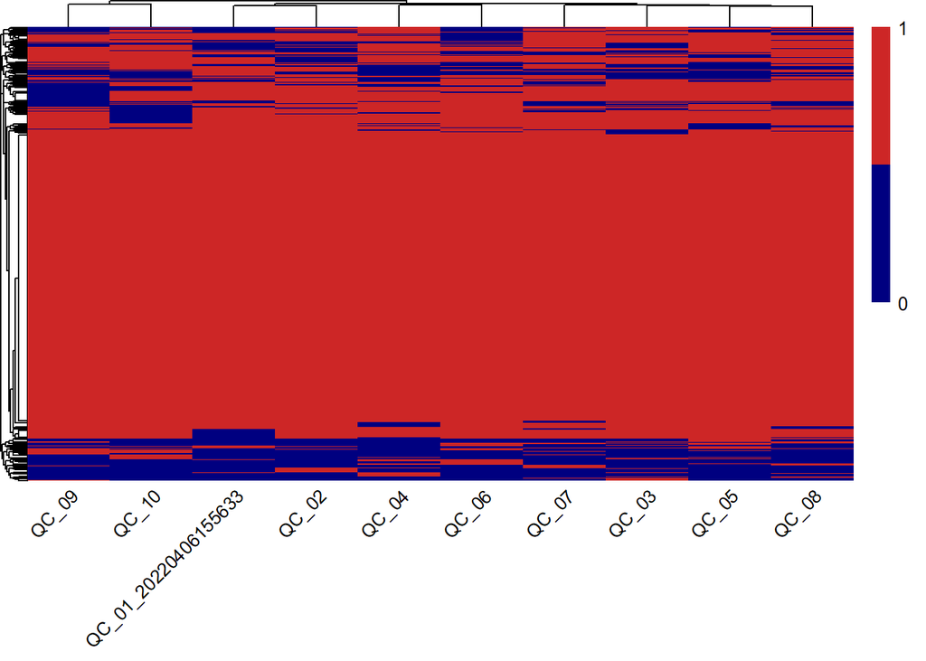

### 4.2.10 results_run9_mqpar_20220406_TR_QC_MBR_rerun_4masterthesis_combined_txt_proteinGroups

Unique.peptides.QC_01_20220406155633  
1294  
Unique.peptides.QC_02  
1329  
Unique.peptides.QC_03  
1319  
Unique.peptides.QC_04  
1317  
Unique.peptides.QC_05  
1341  
Unique.peptides.QC_06  
1347  
Unique.peptides.QC_07  
1365  
Unique.peptides.QC_08  
1343  
Unique.peptides.QC_09  
1306  
Unique.peptides.QC_10  
1302

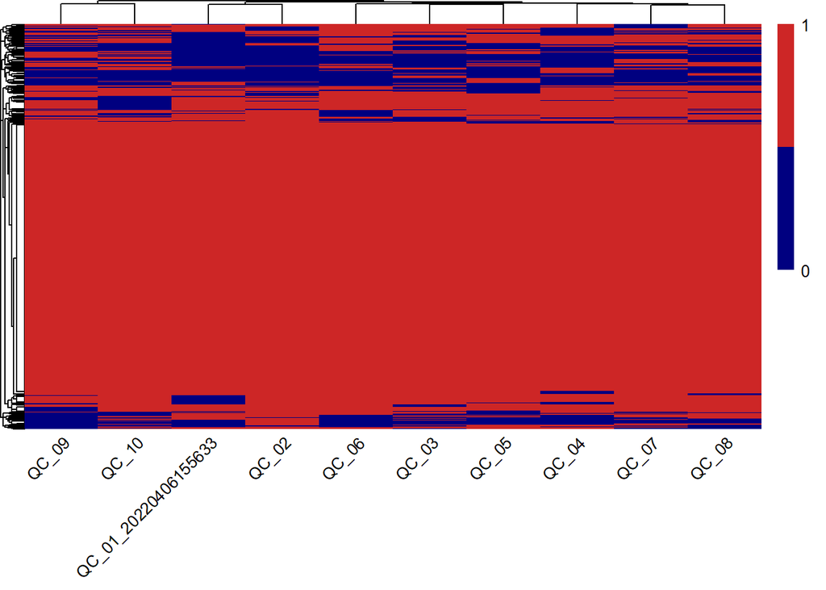

```r
if (LFQ == TRUE) {
  cat("\n")
  cat("##","LFQ","\n")
  cat("\n")
  for (x in file.list){
    cat("\n")
    cat("###",substring(x, 1, nchar(x)-4),"\n")
    data_raw <- as.data.frame(res_raw[[x]])
    data <- filtering(data_raw)

    results <- data.frame(matrix(ncol = length(sample_names_lfq), nrow = nrow(data)))
    colnames(results) <- sample_names_lfq
    i <- 0
    for (i in 1:length(sample_names_lfq)){
      name <- sample_names_lfq[i]
      tmp <- log2(data[name])
      tmp[tmp == -Inf] <- NA
      results[i] <- tmp
      cat(name,"<br/>",sum(!is.na(tmp)),"<br/>")

    }

    results_lfq[[x]] <- results
    results_2gether_lfq[x,] <- sapply(results,function(x)sum(!is.na(x)))
    cat("\n")

    #create heatmaps
    paletteLength <- 50
    myColor <- colorRampPalette(c("navy", "white",
                                  "firebrick3"))(paletteLength)
      data4pheatmap <- results
      data4pheatmap <- results
      data4pheatmap <- data4pheatmap*1
      data4pheatmap[data4pheatmap == 0] <- NA
      # remove NA rows
      ind <- apply(data4pheatmap, 1, function(x) all(is.na(x)))
      data4pheatmap_clear <- data4pheatmap[!ind,]
      data4pheatmap_clear[is.na(data4pheatmap_clear)] <- 0
      if (ncol(data4pheatmap) < 2){
        cat("\n")
        cat("##"," No heatmap possible. Too less columns in the result
            table.","\n")
      } else {
        pheatmap(data4pheatmap_clear,
                 color = myColor,
                 treeheight_row = 10,
                 angle_col ="45",
                 treeheight_col = 10,
                 legend = TRUE,
                 labels_row = rep("",nrow(data4pheatmap)),
                 labels_col = sample_names_raw)
        cat("\n")
      }
  }
}
```

## 4.3 LFQ

### 4.3.1 results_run1_mqpar_20220406_TR_QC_MBR_rerun_4masterthesis_combined_txt_proteinGroups

LFQ.intensity.QC_01_20220406155633  
1258  
LFQ.intensity.QC_02  
1291  
LFQ.intensity.QC_03  
1291  
LFQ.intensity.QC_04  
1301  
LFQ.intensity.QC_05  
1301  
LFQ.intensity.QC_06  
1301  
LFQ.intensity.QC_07  
1323  
LFQ.intensity.QC_08  
1304  
LFQ.intensity.QC_09  
1289  
LFQ.intensity.QC_10  
1274

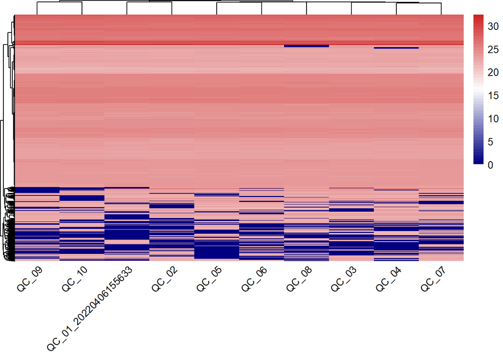

### 4.3.2 results_run10_mqpar_20220406_TR_QC_MBR_rerun_4masterthesis_combined_txt_proteinGroups

LFQ.intensity.QC_01_20220406155633  
1246  
LFQ.intensity.QC_02  
1279  
LFQ.intensity.QC_03  
1274  
LFQ.intensity.QC_04  
1251  
LFQ.intensity.QC_05  
1281  
LFQ.intensity.QC_06  
1246  
LFQ.intensity.QC_07  
1260  
LFQ.intensity.QC_08  
1267  
LFQ.intensity.QC_09  
1216  
LFQ.intensity.QC_10  
1235

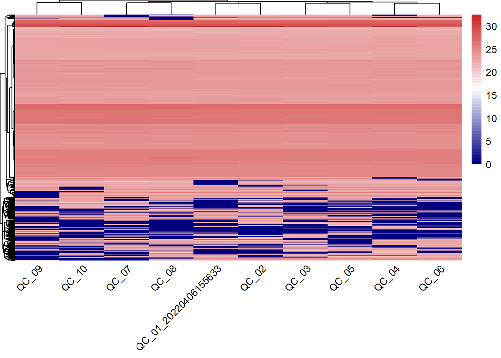

### 4.3.3 results_run2_mqpar_20220406_TR_QC_MBR_rerun_4masterthesis_combined_txt_proteinGroups

LFQ.intensity.QC_01_20220406155633  
1256  
LFQ.intensity.QC_02  
1296  
LFQ.intensity.QC_03  
1290  
LFQ.intensity.QC_04  
1301  
LFQ.intensity.QC_05  
1303  
LFQ.intensity.QC_06  
1301  
LFQ.intensity.QC_07  
1323  
LFQ.intensity.QC_08  
1299  
LFQ.intensity.QC_09  
1287  
LFQ.intensity.QC_10  
1272

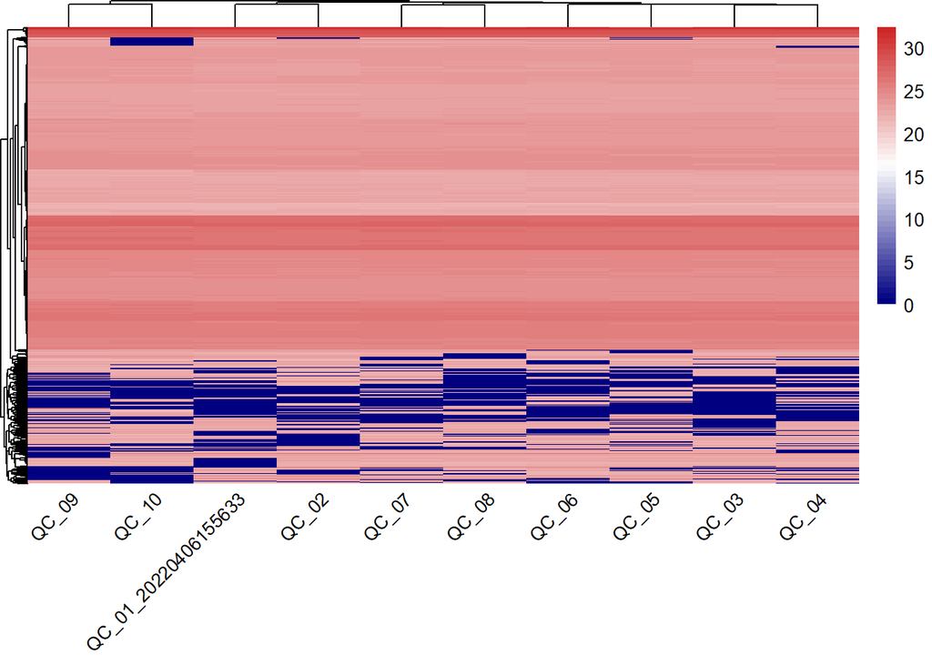

### 4.3.4 results_run3_mqpar_20220406_TR_QC_MBR_rerun_4masterthesis_combined_txt_proteinGroups

LFQ.intensity.QC_01_20220406155633  
1256  
LFQ.intensity.QC_02  
1292  
LFQ.intensity.QC_03  
1291  
LFQ.intensity.QC_04  
1301  
LFQ.intensity.QC_05  
1303  
LFQ.intensity.QC_06  
1302  
LFQ.intensity.QC_07  
1321  
LFQ.intensity.QC_08  
1303  
LFQ.intensity.QC_09  
1294  
LFQ.intensity.QC_10  
1274

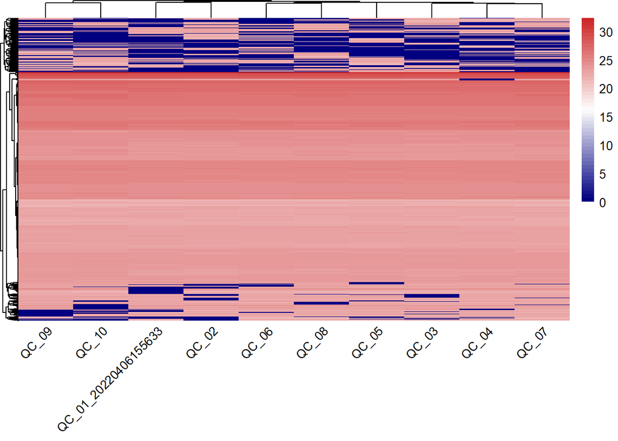

### 4.3.5 results_run4_mqpar_20220406_TR_QC_MBR_rerun_4masterthesis_combined_txt_proteinGroups

LFQ.intensity.QC_01_20220406155633  
1257  
LFQ.intensity.QC_02  
1292  
LFQ.intensity.QC_03  
1286  
LFQ.intensity.QC_04  
1291  
LFQ.intensity.QC_05  
1294  
LFQ.intensity.QC_06  
1296  
LFQ.intensity.QC_07  
1316  
LFQ.intensity.QC_08  
1292  
LFQ.intensity.QC_09  
1267  
LFQ.intensity.QC_10  
1265

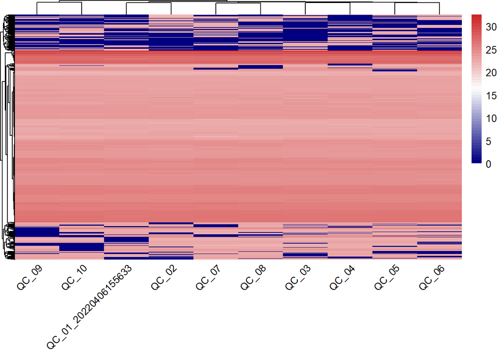

### 4.3.6 results_run5_mqpar_20220406_TR_QC_MBR_rerun_4masterthesis_combined_txt_proteinGroups

LFQ.intensity.QC_01_20220406155633  
1256  
LFQ.intensity.QC_02  
1291  
LFQ.intensity.QC_03  
1291  
LFQ.intensity.QC_04  
1301  
LFQ.intensity.QC_05  
1301  
LFQ.intensity.QC_06  
1301  
LFQ.intensity.QC_07  
1320  
LFQ.intensity.QC_08  
1305  
LFQ.intensity.QC_09  
1290  
LFQ.intensity.QC_10  
1276

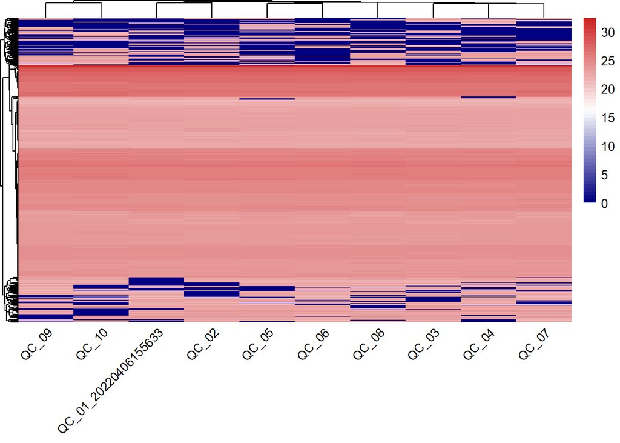

### 4.3.7 results_run6_mqpar_20220406_TR_QC_MBR_rerun_4masterthesis_combined_txt_proteinGroups

LFQ.intensity.QC_01_20220406155633  
1247  
LFQ.intensity.QC_02  
1276  
LFQ.intensity.QC_03  
1278  
LFQ.intensity.QC_04  
1256  
LFQ.intensity.QC_05  
1283  
LFQ.intensity.QC_06  
1263  
LFQ.intensity.QC_07  
1281  
LFQ.intensity.QC_08  
1279  
LFQ.intensity.QC_09  
1227  
LFQ.intensity.QC_10  
1235

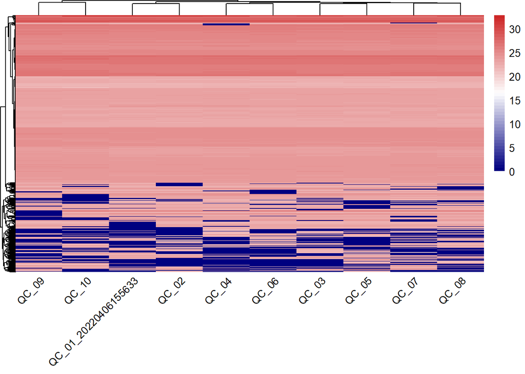

### 4.3.8 results_run7_mqpar_20220406_TR_QC_MBR_rerun_4masterthesis_combined_txt_proteinGroups

LFQ.intensity.QC_01_20220406155633  
1256  
LFQ.intensity.QC_02  
1292  
LFQ.intensity.QC_03  
1290  
LFQ.intensity.QC_04  
1296  
LFQ.intensity.QC_05  
1302  
LFQ.intensity.QC_06  
1300  
LFQ.intensity.QC_07  
1314  
LFQ.intensity.QC_08  
1303  
LFQ.intensity.QC_09  
1289  
LFQ.intensity.QC_10  
1274

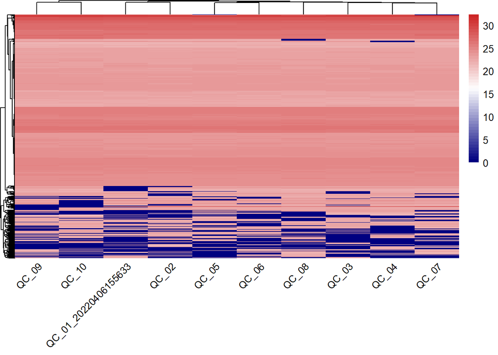

### 4.3.9 results_run8_mqpar_20220406_TR_QC_MBR_rerun_4masterthesis_combined_txt_proteinGroups

LFQ.intensity.QC_01_20220406155633  
1252  
LFQ.intensity.QC_02  
1284  
LFQ.intensity.QC_03  
1284  
LFQ.intensity.QC_04  
1277  
LFQ.intensity.QC_05  
1287  
LFQ.intensity.QC_06  
1278  
LFQ.intensity.QC_07  
1295  
LFQ.intensity.QC_08  
1286  
LFQ.intensity.QC_09  
1250  
LFQ.intensity.QC_10  
1248

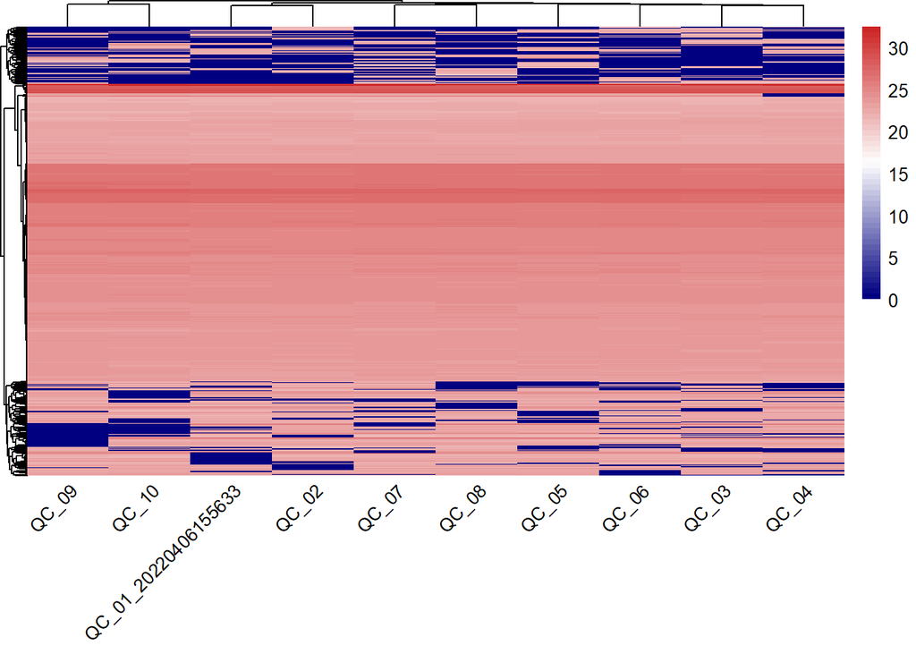

### 4.3.10 results_run9_mqpar_20220406_TR_QC_MBR_rerun_4masterthesis_combined_txt_proteinGroups

LFQ.intensity.QC_01_20220406155633  
1255  
LFQ.intensity.QC_02  
1288  
LFQ.intensity.QC_03  
1286  
LFQ.intensity.QC_04  
1291  
LFQ.intensity.QC_05  
1302  
LFQ.intensity.QC_06  
1299  
LFQ.intensity.QC_07  
1310  
LFQ.intensity.QC_08  
1300  
LFQ.intensity.QC_09  
1286  
LFQ.intensity.QC_10  
1269

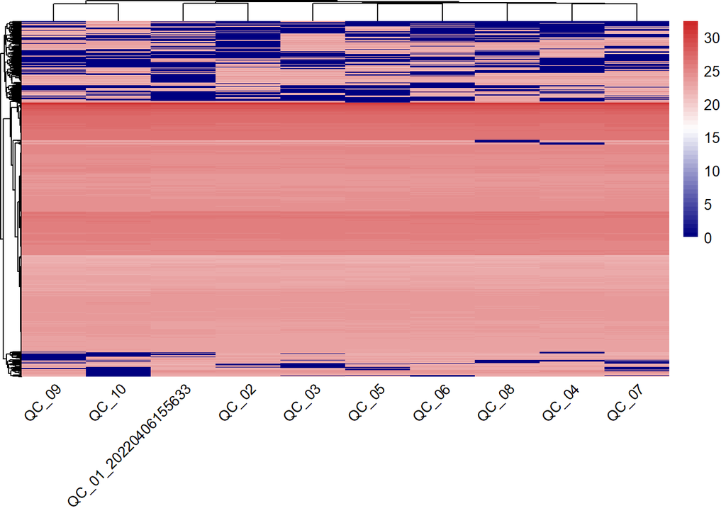

# 5 Summary

```r
# show summary
if (RAZOR == TRUE){
  cat("\n")
  cat("##"," Summary Razor","\n")
  print(kable(results_2gether_razor))

  ggplot(melt(results_2gether_razor),aes(x = variable, y = value)) +
  geom_boxplot() +
  xlab("Sample name") +
  scale_x_discrete(labels = sample_names_raw) +
  theme(axis.text.x = element_text(angle = 90)) +
  labs(title = "Razor")
}
```

## 5.1 Summary Razor

|  | Razor…unique.peptides.QC_01_20220406155633 | Razor…unique.peptides.QC_02 | Razor…unique.peptides.QC_03 | Razor…unique.peptides.QC_04 | Razor…unique.peptides.QC_05 | Razor…unique.peptides.QC_06 | Razor…unique.peptides.QC_07 | Razor…unique.peptides.QC_08 | Razor…unique.peptides.QC_09 | Razor…unique.peptides.QC_10 |
| --- | --- | --- | --- | --- | --- | --- | --- | --- | --- | --- |
| results_run1_mqpar_20220406_TR_QC_MBR_rerun_4masterthesis_combined_txt_proteinGroups.txt | 1327 | 1363 | 1351 | 1357 | 1371 | 1374 | 1397 | 1372 | 1338 | 1330 |
| results_run10_mqpar_20220406_TR_QC_MBR_rerun_4masterthesis_combined_txt_proteinGroups.txt | 1310 | 1344 | 1335 | 1313 | 1343 | 1317 | 1333 | 1343 | 1279 | 1297 |
| results_run2_mqpar_20220406_TR_QC_MBR_rerun_4masterthesis_combined_txt_proteinGroups.txt | 1323 | 1357 | 1350 | 1356 | 1366 | 1372 | 1384 | 1375 | 1332 | 1332 |
| results_run3_mqpar_20220406_TR_QC_MBR_rerun_4masterthesis_combined_txt_proteinGroups.txt | 1324 | 1363 | 1350 | 1354 | 1372 | 1376 | 1395 | 1373 | 1342 | 1331 |
| results_run4_mqpar_20220406_TR_QC_MBR_rerun_4masterthesis_combined_txt_proteinGroups.txt | 1320 | 1353 | 1346 | 1349 | 1362 | 1370 | 1382 | 1371 | 1317 | 1330 |
| results_run5_mqpar_20220406_TR_QC_MBR_rerun_4masterthesis_combined_txt_proteinGroups.txt | 1327 | 1361 | 1350 | 1354 | 1370 | 1373 | 1394 | 1372 | 1336 | 1330 |
| results_run6_mqpar_20220406_TR_QC_MBR_rerun_4masterthesis_combined_txt_proteinGroups.txt | 1310 | 1345 | 1337 | 1315 | 1347 | 1331 | 1356 | 1344 | 1282 | 1300 |
| results_run7_mqpar_20220406_TR_QC_MBR_rerun_4masterthesis_combined_txt_proteinGroups.txt | 1328 | 1362 | 1350 | 1351 | 1372 | 1373 | 1393 | 1370 | 1336 | 1332 |
| results_run8_mqpar_20220406_TR_QC_MBR_rerun_4masterthesis_combined_txt_proteinGroups.txt | 1313 | 1354 | 1344 | 1335 | 1348 | 1347 | 1357 | 1357 | 1298 | 1311 |
| results_run9_mqpar_20220406_TR_QC_MBR_rerun_4masterthesis_combined_txt_proteinGroups.txt | 1325 | 1359 | 1345 | 1345 | 1370 | 1375 | 1392 | 1368 | 1337 | 1333 |

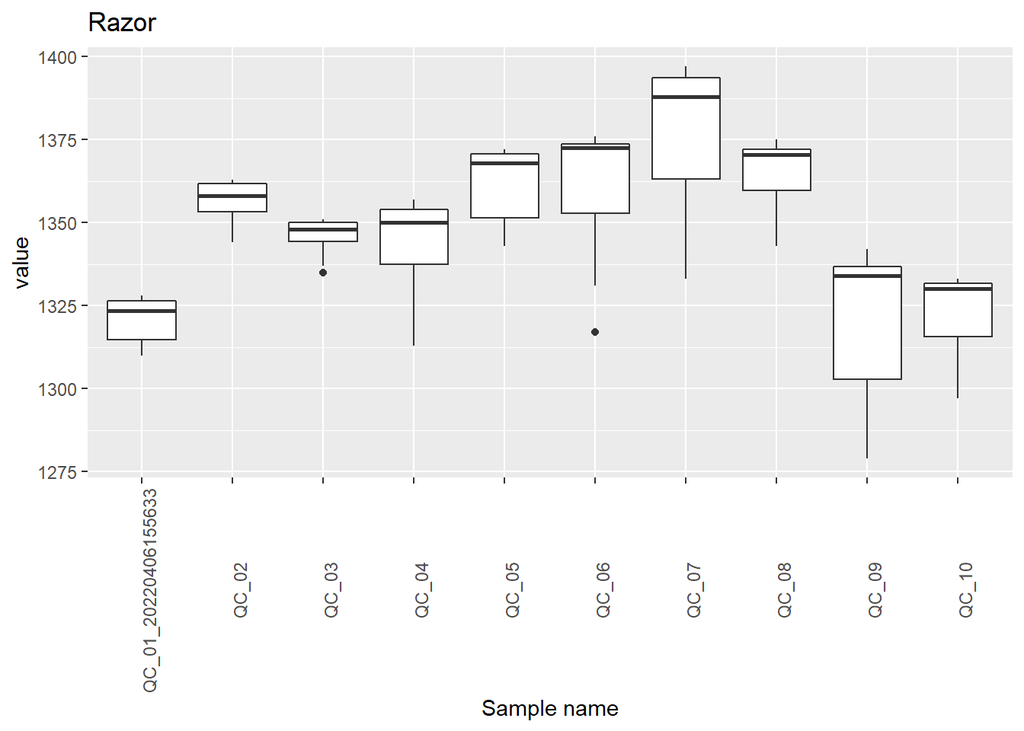

```r
if (UNIQUE == TRUE){
  cat("\n")
  cat("##"," Summary Unique","\n")
  print(kable(results_2gether_unique))

  ggplot(melt(results_2gether_unique),aes(x = variable, y = value)) +
  geom_boxplot() +
  xlab("Sample name") +
  scale_x_discrete(labels = sample_names_raw) +
  theme(axis.text.x = element_text(angle = 90)) +
  labs(title = "Unique")
}
```

## 5.2 Summary Unique

|  | Unique.peptides.QC_01_20220406155633 | Unique.peptides.QC_02 | Unique.peptides.QC_03 | Unique.peptides.QC_04 | Unique.peptides.QC_05 | Unique.peptides.QC_06 | Unique.peptides.QC_07 | Unique.peptides.QC_08 | Unique.peptides.QC_09 | Unique.peptides.QC_10 |
| --- | --- | --- | --- | --- | --- | --- | --- | --- | --- | --- |
| results_run1_mqpar_20220406_TR_QC_MBR_rerun_4masterthesis_combined_txt_proteinGroups.txt | 1296 | 1332 | 1323 | 1329 | 1341 | 1347 | 1368 | 1347 | 1308 | 1299 |
| results_run10_mqpar_20220406_TR_QC_MBR_rerun_4masterthesis_combined_txt_proteinGroups.txt | 1281 | 1314 | 1309 | 1288 | 1314 | 1290 | 1303 | 1319 | 1250 | 1266 |
| results_run2_mqpar_20220406_TR_QC_MBR_rerun_4masterthesis_combined_txt_proteinGroups.txt | 1292 | 1326 | 1325 | 1329 | 1337 | 1344 | 1355 | 1349 | 1302 | 1302 |
| results_run3_mqpar_20220406_TR_QC_MBR_rerun_4masterthesis_combined_txt_proteinGroups.txt | 1292 | 1332 | 1322 | 1326 | 1342 | 1349 | 1367 | 1347 | 1311 | 1299 |
| results_run4_mqpar_20220406_TR_QC_MBR_rerun_4masterthesis_combined_txt_proteinGroups.txt | 1289 | 1321 | 1321 | 1323 | 1333 | 1345 | 1353 | 1347 | 1287 | 1300 |
| results_run5_mqpar_20220406_TR_QC_MBR_rerun_4masterthesis_combined_txt_proteinGroups.txt | 1295 | 1330 | 1322 | 1326 | 1340 | 1345 | 1365 | 1346 | 1305 | 1297 |
| results_run6_mqpar_20220406_TR_QC_MBR_rerun_4masterthesis_combined_txt_proteinGroups.txt | 1282 | 1315 | 1310 | 1290 | 1320 | 1305 | 1328 | 1320 | 1253 | 1269 |
| results_run7_mqpar_20220406_TR_QC_MBR_rerun_4masterthesis_combined_txt_proteinGroups.txt | 1296 | 1331 | 1323 | 1322 | 1341 | 1344 | 1365 | 1344 | 1304 | 1301 |
| results_run8_mqpar_20220406_TR_QC_MBR_rerun_4masterthesis_combined_txt_proteinGroups.txt | 1284 | 1324 | 1319 | 1309 | 1321 | 1322 | 1330 | 1334 | 1270 | 1281 |
| results_run9_mqpar_20220406_TR_QC_MBR_rerun_4masterthesis_combined_txt_proteinGroups.txt | 1294 | 1329 | 1319 | 1317 | 1341 | 1347 | 1365 | 1343 | 1306 | 1302 |

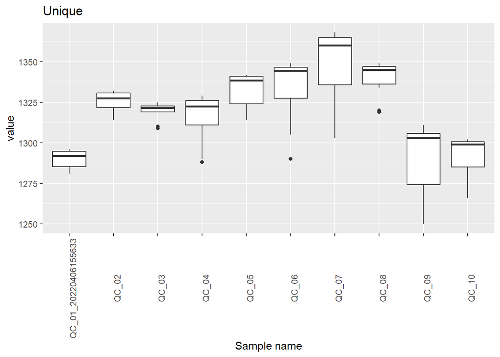

```r
if (LFQ == TRUE){
  cat("\n")
  cat("##"," Summary LFQ","\n")
  print(kable(results_2gether_lfq))

  ggplot(melt(results_2gether_lfq),aes(x = variable, y = value)) +
  geom_boxplot() +
  xlab("Sample name") +
  scale_x_discrete(labels = sample_names_raw) +
  theme(axis.text.x = element_text(angle = 90)) +
  labs(title = "LFQ")
}
```

[output not shown]